# Importing Libraries

```r
library(MASS)
suppressMessages(library(ggplot2))
library(gridExtra)
suppressMessages(library(VIF))
library(caret)
library(corrplot)
library(car)
library(ROCR)
library(e1071)
library(leaps)
suppressMessages(library(Metrics))
suppressMessages(library(glmnet))
library(class)
suppressMessages(library(randomForest))
library(MLmetrics)
library(naivebayes)
```

# Importing Data

```r
results = read.csv("../premier-league/data/results.csv")
stats = read.csv("../premier-league/data/stats.csv")
df0607 = read.csv("../premier-league/data/season-0607.csv")
df0708 = read.csv("../premier-league/data/season-0708.csv")
df0809 = read.csv("../premier-league/data/season-0809.csv")
df0910 = read.csv("../premier-league/data/season-0910.csv")
df1011 = read.csv("../premier-league/data/season-1011.csv")
df1112 = read.csv("../premier-league/data/season-1112.csv")
df1213 = read.csv("../premier-league/data/season-1213.csv")
df1314 = read.csv("../premier-league/data/season-1314.csv")
df1415 = read.csv("../premier-league/data/season-1415.csv")
df1516 = read.csv("../premier-league/data/season-1516.csv")
df1617 = read.csv("../premier-league/data/season-1617.csv")
df1718 = read.csv("../premier-league/data/season-1718.csv")
```

```r
#Checking top few rows of datasets
head(results)
```

```
##          home_team        away_team home_goals away_goals result    season
## 1 Sheffield United        Liverpool          1          1      D 2006-2007
## 2          Arsenal      Aston Villa          1          1      D 2006-2007
## 3          Everton          Watford          2          1      H 2006-2007
## 4 Newcastle United   Wigan Athletic          2          1      H 2006-2007
## 5       Portsmouth Blackburn Rovers          3          0      H 2006-2007
## 6          Reading    Middlesbrough          3          2      H 2006-2007
```

```r
head(stats)
```

```
##                team wins losses goals total_yel_card total_red_card
## 1 Manchester United   28      5    83             60              1
## 2           Chelsea   24      3    64             62              4
## 3         Liverpool   20     10    57             44              0
## 4           Arsenal   19      8    63             59              3
## 5 Tottenham Hotspur   17     12    57             48              3
## 6  Bolton Wanderers   16     14    47             84              4
##   total_scoring_att ontarget_scoring_att hit_woodwork att_hd_goal
## 1               698                  256           21          12
## 2               636                  216           14          16
## 3               668                  214           15           8
## 4               638                  226           19          10
## 5               520                  184            6           5
## 6               404                  120            7          10
##   att_pen_goal att_freekick_goal att_ibox_goal att_obox_goal
```

[output cut: 55 more lines]

```r
head(df0607)
```

```
##   Div       Date   HomeTeam      AwayTeam FTHG FTAG FTR HTHG HTAG HTR
## 1  E0 19-08-2006    Arsenal   Aston Villa    1    1   D    0    0   D
## 2  E0 19-08-2006     Bolton     Tottenham    2    0   H    2    0   H
## 3  E0 19-08-2006    Everton       Watford    2    1   H    1    0   H
## 4  E0 19-08-2006  Newcastle         Wigan    2    1   H    1    0   H
## 5  E0 19-08-2006 Portsmouth     Blackburn    3    0   H    1    0   H
## 6  E0 19-08-2006    Reading Middlesbrough    3    2   H    2    2   D
##      Referee HS AS HST AST HF AF HC AC HY AY HR AR
## 1     G Poll 19  5  11   3 10 19 18  1  1  2  0  0
## 2     P Dowd  8  9   6   6 19 22  6  3  0  1  0  0
## 3   P Walton  6 12   2   8 12 13  0  6  2  2  0  0
## 4 M Atkinson  9 14   8   9 17 20  4 11  1  2  0  0
## 5    A Wiley 21  9  16   7 20 17  6  2  2  1  0  2
## 6   M Halsey 14  7   9   5  8 15  8  2  1  3  0  0
```

```r
#Checking top few rows of season 09-10
head(df0910)
```

```
##         Date    HomeTeam   AwayTeam FTHG FTAG FTR HTHG HTAG HTR
## 1 2009-08-15 Aston Villa      Wigan    0    2   A    0    1   A
## 2 2009-08-15   Blackburn   Man City    0    2   A    0    1   A
## 3 2009-08-15      Bolton Sunderland    0    1   A    0    1   A
## 4 2009-08-15     Chelsea       Hull    2    1   H    1    1   D
## 5 2009-08-15     Everton    Arsenal    1    6   A    0    3   A
## 6 2009-08-15  Portsmouth     Fulham    0    1   A    0    1   A
##         Referee HS AS HST AST HF AF HC AC HY AY HR AR
## 1 M Clattenburg 11 14   5   7 15 14  4  6  2  2  0  0
## 2        M Dean 17  8   9   5 12  9  5  4  2  1  0  0
## 3    A Marriner 11 20   3  13 16 10  4  7  2  1  0  0
## 4       A Wiley 26  7  12   3 13 15 12  4  1  2  0  0
## 5      M Halsey  8 15   5   9 11 13  4  9  0  0  0  0
## 6    M Atkinson 16  9   4   3 11 18  6  4  3  2  0  0
```

```r
#Checking top few rows of season 08-09
head(df0809)
```

[output not shown]

[output cut: 27 more lines]

# Data Cleaning and Wrangling.

```r
#removing unwanted columns in season 2006-2008 to maake total columns consistent from season 2006-2018
df0607  <- df0607[2:23]
df0708  <- df0708[2:23]
df0809  <- df0809[2:23]
```

```r
#checking number of rows and columns in a seasons dataframe
dim(df0708)
```

```
## [1] 380  22
```

```r
dim(df1718)
```

```
## [1] 380  22
```

```r
dim(df1415)
```

```
## [1] 380  22
```

### Merging season 2006-2018 dataframs

```r
df  <- do.call("rbind", list(df0607,df0708,df0809,df0910,df1011,df1112,df1213,df1314,df1415,df1516,df1617,df1718))
```

```r
#checking number of rows and columns in the new dataframe
dim(df)
```

```
## [1] 4560   22
```

The merged data frame has total 380*12 = 4560 rows which is correct expected output.

```r
#Checking top few rows of dataframe
head(df)
```

```
##         Date   HomeTeam      AwayTeam FTHG FTAG FTR HTHG HTAG HTR
## 1 19-08-2006    Arsenal   Aston Villa    1    1   D    0    0   D
## 2 19-08-2006     Bolton     Tottenham    2    0   H    2    0   H
## 3 19-08-2006    Everton       Watford    2    1   H    1    0   H
## 4 19-08-2006  Newcastle         Wigan    2    1   H    1    0   H
## 5 19-08-2006 Portsmouth     Blackburn    3    0   H    1    0   H
## 6 19-08-2006    Reading Middlesbrough    3    2   H    2    2   D
##      Referee HS AS HST AST HF AF HC AC HY AY HR AR
## 1     G Poll 19  5  11   3 10 19 18  1  1  2  0  0
## 2     P Dowd  8  9   6   6 19 22  6  3  0  1  0  0
## 3   P Walton  6 12   2   8 12 13  0  6  2  2  0  0
## 4 M Atkinson  9 14   8   9 17 20  4 11  1  2  0  0
## 5    A Wiley 21  9  16   7 20 17  6  2  2  1  0  2
## 6   M Halsey 14  7   9   5  8 15  8  2  1  3  0  0
```

```r
#saving the dataframe df data into a csv file
write.csv(df, file = "../premier-league/data/season06-18.csv",row.names=FALSE)
```

### Incorrect values in saves column in stats dataframe

```r
#checking structure of stats dataset
str(stats)
```

```
## 'data.frame':    240 obs. of  43 variables:
##  $ team                : Factor w/ 39 levels "AFC Bournemouth",..: 22 12 20 2 34 7 28 5 15 26 ...
##  $ wins                : int  28 24 20 19 17 16 16 15 15 14 ...
##  $ losses              : int  5 3 10 8 12 14 15 16 10 12 ...
##  $ goals               : int  83 64 57 63 57 47 52 52 52 45 ...
##  $ total_yel_card      : int  60 62 44 59 48 84 38 77 65 48 ...
##  $ total_red_card      : int  1 4 0 3 3 4 3 6 2 1 ...
##  $ total_scoring_att   : int  698 636 668 638 520 404 419 478 465 525 ...
##  $ ontarget_scoring_att: int  256 216 214 226 184 120 132 155 153 186 ...
##  $ hit_woodwork        : int  21 14 15 19 6 7 8 5 9 9 ...
##  $ att_hd_goal         : int  12 16 8 10 5 10 15 12 9 13 ...
##  $ att_pen_goal        : int  5 3 6 10 6 6 3 5 8 2 ...
##  $ att_freekick_goal   : int  1 6 1 3 2 0 0 3 2 0 ...
##  $ att_ibox_goal       : int  72 41 46 53 44 38 42 43 44 32 ...
##  $ att_obox_goal       : int  11 23 11 10 13 9 10 9 8 13 ...
```

[output cut: 29 more lines]

```r
#Checking unique values in season column
unique(stats$season)
```

```
##  [1] 2006-2007 2007-2008 2008-2009 2009-2010 2010-2011 2011-2012 2012-2013
##  [8] 2013-2014 2014-2015 2015-2016 2016-2017 2017-2018
## 12 Levels: 2006-2007 2007-2008 2008-2009 2009-2010 2010-2011 ... 2017-2018
```

```r
#lookimg for inconsistent vlaues in saves colum for 2007/2008 season.
stats[stats$season=='2007-2008',c('team','saves')]
```

```
##                 team saves
## 21 Manchester United     2
## 22           Chelsea     4
## 23           Arsenal     0
## 24         Liverpool     0
## 25           Everton     0
## 26       Aston Villa     3
## 27        Portsmouth     4
## 28  Blackburn Rovers     0
## 29   Manchester City     4
## 30   West Ham United     1
## 31  Newcastle United     0
## 32        Sunderland     0
## 33 Tottenham Hotspur     0
## 34     Middlesbrough     0
## 35           Reading     7
## 36    Wigan Athletic     5
## 37  Bolton Wanderers     0
## 38   Birmingham City     0
## 39            Fulham     0
## 40      Derby County     8
```

```r
#lookimg for inconsistent vlaues in saves colum for 2006/2007 season.
stats[stats$season=='2006-2007',c('team','saves')]
```

```
##                 team saves
## 1  Manchester United     2
## 2            Chelsea     4
## 3          Liverpool     1
## 4            Arsenal     6
## 5  Tottenham Hotspur    11
## 6   Bolton Wanderers    13
## 7            Reading     4
## 8   Blackburn Rovers    22
## 9            Everton     5
## 10        Portsmouth    14
## 11     Middlesbrough    18
## 12   West Ham United     4
## 13       Aston Villa     1
## 14   Manchester City     0
## 15  Newcastle United     5
## 16  Sheffield United     3
## 17    Wigan Athletic    13
## 18 Charlton Athletic     5
## 19            Fulham    12
## 20           Watford    17
```

```r
#lookimg for inconsistent vlaues in saves colum for 2008/2009 season.
stats[stats$season=='2008-2009',c('team','saves')]
```

```
##                    team saves
## 41    Manchester United    NA
## 42              Chelsea    NA
## 43            Liverpool    NA
## 44              Arsenal    NA
## 45          Aston Villa    NA
## 46              Everton    NA
## 47      Manchester City    NA
## 48               Fulham    NA
## 49    Tottenham Hotspur    NA
## 50      West Ham United    NA
## 51           Stoke City    NA
## 52       Wigan Athletic    NA
## 53     Bolton Wanderers    NA
## 54     Blackburn Rovers    NA
## 55           Portsmouth    NA
## 56           Sunderland    NA
## 57            Hull City    NA
## 58 West Bromwich Albion    NA
## 59        Middlesbrough    NA
## 60     Newcastle United    NA
```

Saves column values from season 2006/2007 - 2012/2013 were not recorded properly.

```r
#missing dispossed values in season 2006/2007
stats[stats$season == '2006-2007',c('team','dispossessed')]
```

```
##                 team dispossessed
## 1  Manchester United           NA
## 2            Chelsea           NA
## 3          Liverpool           NA
## 4            Arsenal           NA
## 5  Tottenham Hotspur           NA
## 6   Bolton Wanderers           NA
## 7            Reading           NA
## 8   Blackburn Rovers           NA
## 9            Everton           NA
## 10        Portsmouth           NA
## 11     Middlesbrough           NA
## 12   West Ham United           NA
## 13       Aston Villa           NA
## 14   Manchester City           NA
## 15  Newcastle United           NA
## 16  Sheffield United           NA
## 17    Wigan Athletic           NA
## 18 Charlton Athletic           NA
## 19            Fulham           NA
## 20           Watford           NA
```

```r
#checking number of rows with NA values is stats dataset
sum(!complete.cases(stats))
```

```
## [1] 80
```

```r
#looking at top few rows where the data is missing.
head(stats[!complete.cases(stats),])
```

```
##                team wins losses goals total_yel_card total_red_card
## 1 Manchester United   28      5    83             60              1
## 2           Chelsea   24      3    64             62              4
## 3         Liverpool   20     10    57             44              0
## 4           Arsenal   19      8    63             59              3
## 5 Tottenham Hotspur   17     12    57             48              3
## 6  Bolton Wanderers   16     14    47             84              4
##   total_scoring_att ontarget_scoring_att hit_woodwork att_hd_goal
## 1               698                  256           21          12
## 2               636                  216           14          16
## 3               668                  214           15           8
## 4               638                  226           19          10
## 5               520                  184            6           5
## 6               404                  120            7          10
##   att_pen_goal att_freekick_goal att_ibox_goal att_obox_goal
```

[output cut: 55 more lines]

```r
#missing values in big_chance_missed column in stats data frame
stats[is.na(stats$big_chance_missed),c('team','big_chance_missed','season')]
```

```
##                       team big_chance_missed    season
## 1        Manchester United                NA 2006-2007
## 2                  Chelsea                NA 2006-2007
## 3                Liverpool                NA 2006-2007
## 4                  Arsenal                NA 2006-2007
## 5        Tottenham Hotspur                NA 2006-2007
## 6         Bolton Wanderers                NA 2006-2007
## 7                  Reading                NA 2006-2007
## 8         Blackburn Rovers                NA 2006-2007
## 9                  Everton                NA 2006-2007
## 10              Portsmouth                NA 2006-2007
## 11           Middlesbrough                NA 2006-2007
## 12         West Ham United                NA 2006-2007
## 13             Aston Villa                NA 2006-2007
## 14         Manchester City                NA 2006-2007
```

[output cut: 66 more lines]

```r
#Adding total games played column to the stats dataframe
stats$total_games  <- rep(38,nrow(stats))
```

```r
#Displaying top few rows of the stats dataset.
head(stats)
```

```
##                team wins losses goals total_yel_card total_red_card
## 1 Manchester United   28      5    83             60              1
## 2           Chelsea   24      3    64             62              4
## 3         Liverpool   20     10    57             44              0
## 4           Arsenal   19      8    63             59              3
## 5 Tottenham Hotspur   17     12    57             48              3
## 6  Bolton Wanderers   16     14    47             84              4
##   total_scoring_att ontarget_scoring_att hit_woodwork att_hd_goal
## 1               698                  256           21          12
## 2               636                  216           14          16
## 3               668                  214           15           8
## 4               638                  226           19          10
## 5               520                  184            6           5
## 6               404                  120            7          10
##   att_pen_goal att_freekick_goal att_ibox_goal att_obox_goal
```

[output cut: 55 more lines]

```r
#saving the stats dataframe
write.csv(stats,file = "../premier-league/data/stats.csv",row.names=FALSE)
```

```r
#Importing the stats dataframe
stats  <- read.csv("../premier-league/data/stats.csv")
```

# Adding manager data to Manchester united

```r
#seperating Manchester united column from stats table
ManUnited  <- stats[stats$team == 'Manchester United',]
```

```r
#Top few rows of the dataframe
head(ManUnited)
```

```
##                  team wins losses goals total_yel_card total_red_card
## 1   Manchester United   28      5    83             60              1
## 21  Manchester United   27      5    80             51              2
## 41  Manchester United   28      4    68             61              5
## 62  Manchester United   27      7    86             49              4
## 81  Manchester United   23      4    78             56              3
## 102 Manchester United   28      5    89             51              1
##     total_scoring_att ontarget_scoring_att hit_woodwork att_hd_goal
## 1                 698                  256           21          12
## 21                696                  260           16          12
## 41                715                  230            9           7
## 62                695                  221           12          14
## 81                618                  212           15          18
## 102               646                  243           17          16
##     att_pen_goal att_freekick_goal att_ibox_goal att_obox_goal
```

[output cut: 55 more lines]

```r
#resetting rownames
rownames(ManUnited) <- NULL
```

```r
#Adding Manager data
ManUnited$manager  <- rep("Alex Ferguson",nrow(ManUnited))
ManUnited[ManUnited$season == "2013-2014","manager"]  <- "David Moyes"
ManUnited[ManUnited$season == "2014-2015","manager"]  <- "Louis van Gaal"
ManUnited[ManUnited$season == "2015-2016","manager"]  <- "Louis van Gaal"
ManUnited[ManUnited$season == "2016-2017","manager"]  <- "Jose Mourinho"
ManUnited[ManUnited$season == "2017-2018","manager"]  <- "Jose Mourinho"
```

```r
#Manchester united dataframe
head(ManUnited)
```

```
##                team wins losses goals total_yel_card total_red_card
## 1 Manchester United   28      5    83             60              1
## 2 Manchester United   27      5    80             51              2
## 3 Manchester United   28      4    68             61              5
## 4 Manchester United   27      7    86             49              4
## 5 Manchester United   23      4    78             56              3
## 6 Manchester United   28      5    89             51              1
##   total_scoring_att ontarget_scoring_att hit_woodwork att_hd_goal
## 1               698                  256           21          12
## 2               696                  260           16          12
## 3               715                  230            9           7
## 4               695                  221           12          14
## 5               618                  212           15          18
## 6               646                  243           17          16
##   att_pen_goal att_freekick_goal att_ibox_goal att_obox_goal
```

[output cut: 55 more lines]

```r
#saving the Manchester United dataframe as a csv file
write.csv(ManUnited, file = "../premier-league/data/ManU.csv",row.names=FALSE)
```

# Extracting Leicester City stats from stats dataframe

```r
#checking unique names in team column
unique(stats$team)
```

```
##  [1] Manchester United        Chelsea
##  [3] Liverpool                Arsenal
##  [5] Tottenham Hotspur        Bolton Wanderers
##  [7] Reading                  Blackburn Rovers
##  [9] Everton                  Portsmouth
## [11] Middlesbrough            West Ham United
## [13] Aston Villa              Manchester City
## [15] Newcastle United         Sheffield United
## [17] Wigan Athletic           Charlton Athletic
## [19] Fulham                   Watford
## [21] Sunderland               Birmingham City
## [23] Derby County             Stoke City
## [25] Hull City                West Bromwich Albion
## [27] Wolverhampton Wanderers  Burnley
## [29] Blackpool                Norwich City
## [31] Swansea City             Queens Park Rangers
## [33] Southampton              Crystal Palace
## [35] Cardiff City             Leicester City
## [37] AFC Bournemouth          Brighton and Hove Albion
## [39] Huddersfield Town
## 39 Levels: AFC Bournemouth Arsenal Aston Villa ... Wolverhampton Wanderers
```

```r
#extracting leicester city data from stats dataframe
Leicester  <- stats[stats$team=='Leicester City',]
```

```r
Leicester
```

```
##               team wins losses goals total_yel_card total_red_card
## 173 Leicester City   11     19    46             49              4
## 181 Leicester City   23      3    68             48              3
## 210 Leicester City   12     18    48             72              1
## 229 Leicester City   12     15    56             52              5
##     total_scoring_att ontarget_scoring_att hit_woodwork att_hd_goal
## 173               456                  137           12           7
## 181               522                  179           11          11
## 210               433                  145            8          10
## 229               423                  149            8           9
##     att_pen_goal att_freekick_goal att_ibox_goal att_obox_goal
## 173            3                 0            38             8
## 181           10                 0            65             3
## 210            4                 1            39             9
## 229            5                 1            49             7
```

[output cut: 35 more lines]

```r
#saving the file
write.csv(Leicester,file="../premier-league/data/leicester.csv",row.names=FALSE)
```

# Makings Predictions using Seasons dataset.

```r
#Importing seasons dataset.
seasons <- read.csv("../premier-league/data/season06-18.csv")
```

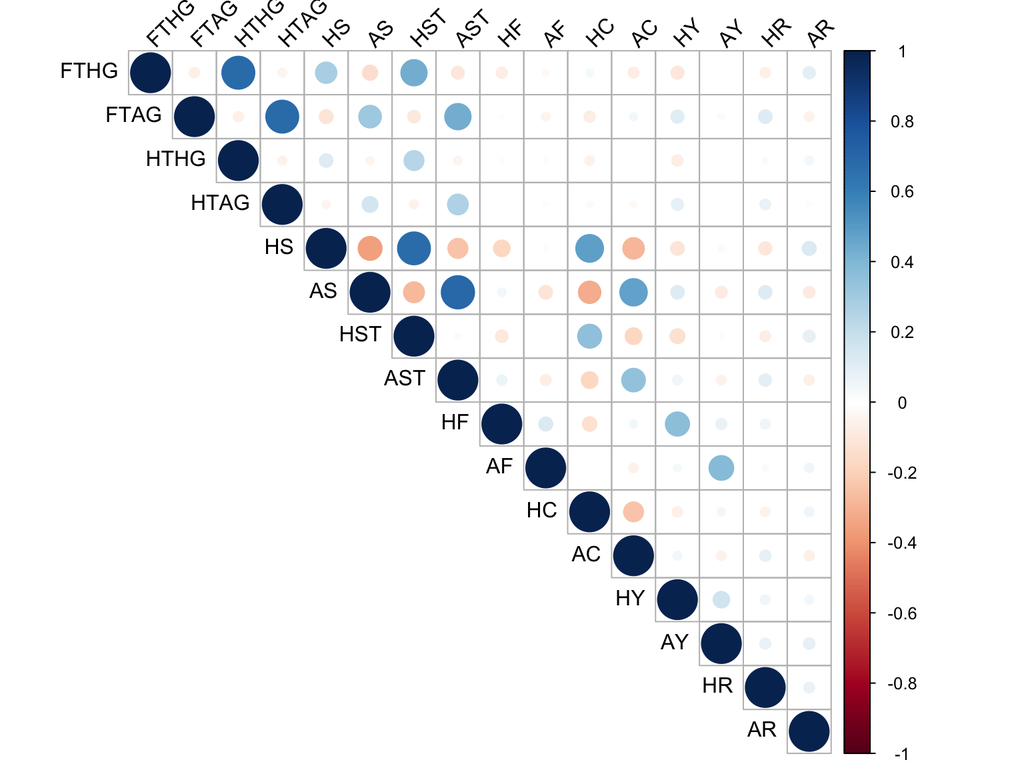

```r
#Correlation Plot
corrplot(cor(seasons[,c(-1,-2,-3,-6,-9,-10)]), type = "upper", order = "original",
         tl.col = "black", tl.srt = 45)
```

From the above plot we can see that FTHG, FTAG are correlated with HTHG,HTAG because these values are related to number of goals made by Home team and Away team during Half time and Full time of the match. This goes the same for other predictor pairs like HS(home team shots),AS(Away team shots) with HST(Home team shots on target) and AST(Away team shots on target), as they indicate how many shots,shots on target home team and away team made.

## Decision Boundary

```r
decisionplot <- function(model, data, class = NULL, predict_type = "class",
  resolution = 100, showgrid = TRUE, ...) {

  if(!is.null(class)) cl <- data[,class] else cl <- 1
  data <- data[,1:2]
  k <- length(unique(cl))

  plot(data, col = as.integer(cl)+1L, pch = as.integer(cl)+1L, ...)

  # make grid
  r <- sapply(data, range, na.rm = TRUE)
  xs <- seq(r[1,1], r[2,1], length.out = resolution)
  ys <- seq(r[1,2], r[2,2], length.out = resolution)
  g <- cbind(rep(xs, each=resolution), rep(ys, time = resolution))
  colnames(g) <- colnames(r)
  g <- as.data.frame(g)

  p <- predict(model, g, type = predict_type)
  if(is.list(p)) p <- p$class
  p <- as.factor(p)

  if(showgrid) points(g, col = as.integer(p)+1L, pch = ".")

  z <- matrix(as.integer(p), nrow = resolution, byrow = TRUE)
  contour(xs, ys, z, add = TRUE, drawlabels = FALSE,
    lwd = 2, levels = (1:(k-1))+.5)

  invisible(z)
}
```

```r
#checking top few rows of dataset
head(seasons)
```

```
##         Date   HomeTeam      AwayTeam FTHG FTAG FTR HTHG HTAG HTR
## 1 19-08-2006    Arsenal   Aston Villa    1    1   D    0    0   D
## 2 19-08-2006     Bolton     Tottenham    2    0   H    2    0   H
## 3 19-08-2006    Everton       Watford    2    1   H    1    0   H
## 4 19-08-2006  Newcastle         Wigan    2    1   H    1    0   H
## 5 19-08-2006 Portsmouth     Blackburn    3    0   H    1    0   H
## 6 19-08-2006    Reading Middlesbrough    3    2   H    2    2   D
##      Referee HS AS HST AST HF AF HC AC HY AY HR AR
## 1     G Poll 19  5  11   3 10 19 18  1  1  2  0  0
## 2     P Dowd  8  9   6   6 19 22  6  3  0  1  0  0
## 3   P Walton  6 12   2   8 12 13  0  6  2  2  0  0
## 4 M Atkinson  9 14   8   9 17 20  4 11  1  2  0  0
## 5    A Wiley 21  9  16   7 20 17  6  2  2  1  0  2
## 6   M Halsey 14  7   9   5  8 15  8  2  1  3  0  0
```

### Train Test Split

```r
#splitting data into train and test
set.seed(100)
trainIndex <- createDataPartition(seasons$FTR,times=1,p=0.8,list=F)
train <- seasons[trainIndex,]
test <- seasons[-trainIndex,]
```

## LDA

### Fitting our model

```r
#fitting the model
lda.fit <- lda(FTR~.,data=data.frame(train[,c(-1,-10)]))
```

```r
#making predictions on train dataset
lda.pred.train <- predict(lda.fit,train[,c(-1,-10)])
```

```r
#checking the accuracy in train dataset
mean(lda.pred.train$class==train$FTR)
```

```
## [1] 0.8862702
```

The accuracy is aroung 88% on train data.

```r
#making predictions on test dataset
lda.pred <- predict(lda.fit,test[,c(-1,-10)])
```

### Metric calculations

```r
#getting predicted classes and displaying a confusion matrix
lda.class <- lda.pred$class
table(lda.class,test$FTR)
```

```
##
## lda.class   A   D   H
##         A 201  17   0
##         D  55 205  50
##         H   0  11 372
```

```r
#checking the accuracy of our results
mean(lda.class==test$FTR)
```

```
## [1] 0.8540066
```

Accuracy on a random choosen test data is 85.4%.

```r
#calculating Precision
Precision(y_pred=lda.class,y_true=test$FTR)
```

```
## [1] 0.9220183
```

```r
#calculating Recall
Recall(y_pred=lda.class,y_true=test$FTR)
```

```
## [1] 0.7851562
```

```r
#calculating F1 Score
F1_Score(y_pred=lda.class,y_true=test$FTR)
```

```
## [1] 0.8481013
```

### Using 10-fold cross validation on LDA.

```r
#using trainControl and train functions to find test error using 10-fold cross validation
ctrl  <- trainControl(method="cv",number = 10)
lda.fit1  <- train(FTR~.,data=seasons[,c(-1,-10)],method="lda",trControl=ctrl)
```

```r
#checing the details of the fit
lda.fit1
```

```
## Linear Discriminant Analysis
##
## 4560 samples
##   19 predictor
##    3 classes: 'A', 'D', 'H'
##
## No pre-processing
## Resampling: Cross-Validated (10 fold)
## Summary of sample sizes: 4104, 4104, 4104, 4104, 4105, 4103, ...
## Resampling results:
##
##   Accuracy   Kappa
##   0.8644797  0.7914261
```

The accuracy has improved when LDA is used with cross-validation.

```r
#making predictions on test dataset
lda.pred1 <- predict(lda.fit1,test[,c(-1,-10)])
```

### Metric calculations

```r
#Confusion matrix
table(lda.pred1,test$FTR)
```

```
##
## lda.pred1   A   D   H
##         A 207  16   0
##         D  49 213  42
##         H   0   4 380
```

```r
#Checking the accuracy on test dataset
mean(lda.pred1==test$FTR)
```

```
## [1] 0.8781559
```

Using 10-fold cross validation to predict on random test dataset has improved accuray by around 2%.

```r
#calculating Precision
Precision(y_pred=lda.pred1,y_true=test$FTR)
```

```
## [1] 0.9282511
```

```r
#calculating Recall
Recall(y_pred=lda.pred1,y_true=test$FTR)
```

```
## [1] 0.8085938
```

```r
#calculating F1 Score
F1_Score(y_pred=lda.pred1,y_true=test$FTR)
```

```
## [1] 0.8643006
```

### Decision Boundry for LDA

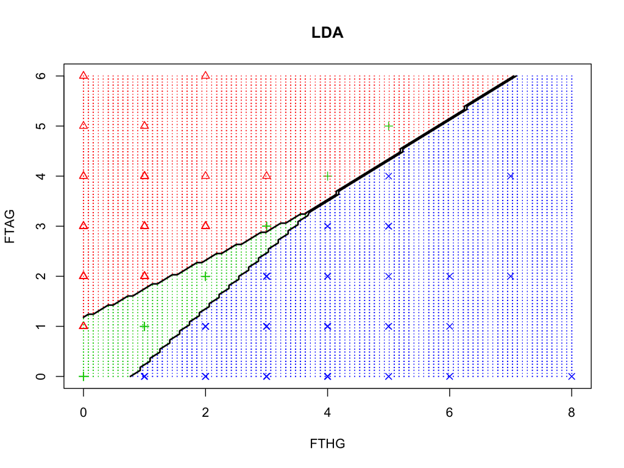

```r
model <- lda(FTR ~., data=train[,c(4,5,6)])
decisionplot(model, test[,c(4,5,6)] ,class = "FTR", main = "LDA")
```

## Ridge for Mutilnomial models.

### Fitting our model

```r
#Before passing our predictors into Ridge for fitting we are converting them into matrix form
x <- model.matrix(FTR~.,data.frame(train[,c(-1,-10)]))[,-1]
y <- train$FTR
```

```r
#Fitting the model
grid <- seq(1,100,length=100)
ridge.fit <- glmnet(x,y,alpha = 0,lambda=grid,family = "multinomial", type.multinomial = "grouped")
```

```r
#plot(ridge.fit,xvar="lambda",label=T)
```

```r
#using cross validation to find the minimum lambda value
cvfit=cv.glmnet(x, y, family="multinomial",alpha=0, type.multinomial = "grouped", parallel = TRUE)
```

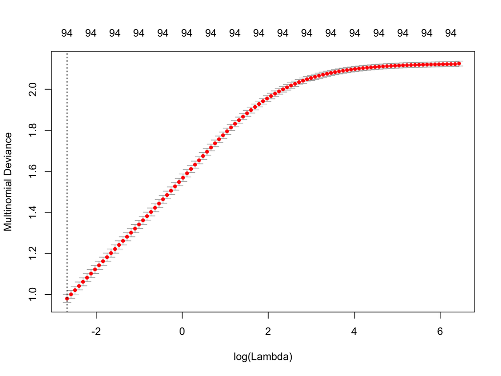

```r
plot(cvfit)
```

```r
#Finiding Minimum lambda value
cvfit$lambda.min
```

```
## [1] 0.06857906
```

```r
#making predictions on test data using minimum lambda value
ridge.predict <- predict(cvfit, newx =  model.matrix(FTR~.,data.frame(test[,c(-1,-10)]))[,-1], s = "lambda.min", type = "class")
```

### Metric calculations

```r
#confusion matrix
table(ridge.predict,test$FTR)
```

```
##
## ridge.predict   A   D   H
##             A 213  37   4
##             D  39 132  21
##             H   4  64 397
```

```r
#calculating test accuracy
mean(ridge.predict==test$FTR)*100
```

```
## [1] 81.44896
```

The test accuracy has resulted in around 81.4%.

```r
#calculating Precision
Precision(y_pred=ridge.predict,y_true=test$FTR)
```

```
## [1] 0.8385827
```

```r
#calculating Recall
Recall(y_pred=ridge.predict,y_true=test$FTR)
```

```
## [1] 0.8320312
```

```r
#calculating F1 Score
F1_Score(y_pred=ridge.predict,y_true=test$FTR)
```

```
## [1] 0.8352941
```

## NaiveBayes

### Fitting our model

```r
#Fitting a model
nb_model<-naiveBayes(FTR~.,data=train[,c(-1,-10)])
```

```r
#making predictions
nb_test_predict <- predict(nb_model,test[,c(-1,-10)])
```

### Metric calculations

```r
#Confusion Matrix
conf_matrix <- table(nb_test_predict, test$FTR)
conf_matrix
```

```
##
## nb_test_predict   A   D   H
##               A 174  43   9
##               D  72 131  75
##               H  10  59 338
```

```r
#calculating accuracy on test data
mean(nb_test_predict==test$FTR)*100
```

```
## [1] 70.58178
```

```r
#calculating Precision
Precision(y_pred=nb_test_predict,y_true=test$FTR)
```

```
## [1] 0.7699115
```

```r
#calculating Recall
Recall(y_pred=nb_test_predict,y_true=test$FTR)
```

```
## [1] 0.6796875
```

```r
#calculating F1 Score
F1_Score(y_pred=nb_test_predict,y_true=test$FTR)
```

```
## [1] 0.7219917
```

### Naive Bayes Decision Boundary

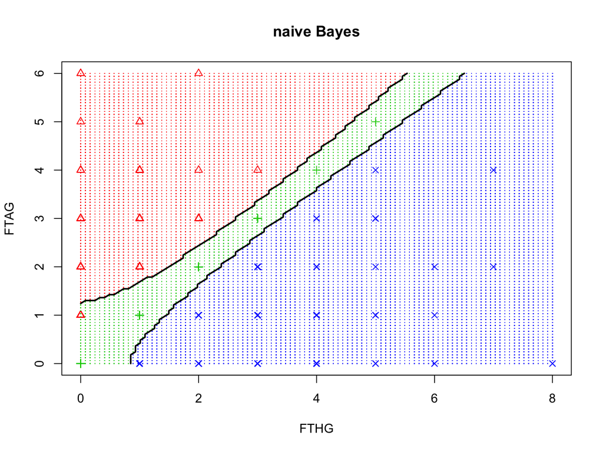

```r
model <- naiveBayes(FTR ~ ., data=train[,c(4,5,6)])
decisionplot(model,test[,c(4,5,6)], class = "FTR", main = "naive Bayes")
```

## KNN

### Fitting our model

```r
#using trainControl and train functions to find test error using 10-fold cross validation
repeats = 3
numbers = 10
tunel = 10

x = trainControl(method = "repeatedcv",
                 number = numbers,
                 repeats = repeats,
                 classProbs = TRUE,
                 summaryFunction = multiClassSummary)
```

```r
knn_model <- train(FTR~. , data = train[,c(-1,-10)], method = "knn",
               preProcess = c("center","scale"),
               trControl = x,
               metric = "logLoss",
               tuneLength = tunel)
```

```r
#summary of the model
knn_model
```

```
## k-Nearest Neighbors
##
## 3649 samples
##   19 predictor
##    3 classes: 'A', 'D', 'H'
##
## Pre-processing: centered (94), scaled (94)
## Resampling: Cross-Validated (10 fold, repeated 3 times)
## Summary of sample sizes: 3284, 3283, 3283, 3285, 3285, 3285, ...
## Resampling results across tuning parameters:
##
##   k   logLoss    AUC        prAUC      Accuracy   Kappa      Mean_F1
##    5  4.0348140  0.7121050  0.4664615  0.5659201  0.3098032  0.5176614
##    7  2.6563230  0.7313215  0.5292623  0.5809946  0.3284251  0.5277686
##    9  1.8752089  0.7417942  0.5626829  0.5875705  0.3361595  0.5294677
##   11  1.4367395  0.7505870  0.5771598  0.5999814  0.3557461  0.5422673
##   13  1.1934290  0.7537230  0.5870327  0.6043738  0.3615357  0.5435997
##   15  1.0395166  0.7597612  0.5955005  0.6063787  0.3630327  0.5419656
##   17  0.9714928  0.7640294  0.6033603  0.6094842  0.3669001  0.5431902
##   19  0.9289165  0.7674388  0.6080281  0.6145068  0.3751751  0.5477716
##   21  0.9082926  0.7709252  0.6120212  0.6172516  0.3795444  0.5489879
##   23  0.8804427  0.7733479  0.6149699  0.6174364  0.3791720  0.5490652
##   Mean_Sensitivity  Mean_Specificity  Mean_Pos_Pred_Value
##   0.5210904         0.7720446         0.5209812
##   0.5309686         0.7774511         0.5359506
##   0.5340832         0.7798013         0.5396749
##   0.5463383         0.7861095         0.5539628
##   0.5492848         0.7878873         0.5568743
##   0.5487737         0.7883208         0.5568482
##   0.5507029         0.7893530         0.5596965
##   0.5561850         0.7920095         0.5657000
##   0.5585906         0.7934943         0.5668573
##   0.5582516         0.7931937         0.5690904
##   Mean_Neg_Pred_Value  Mean_Precision  Mean_Recall  Mean_Detection_Rate
##   0.7793161            0.5209812       0.5210904    0.1886400
##   0.7883356            0.5359506       0.5309686    0.1936649
##   0.7931984            0.5396749       0.5340832    0.1958568
##   0.8004235            0.5539628       0.5463383    0.1999938
##   0.8036636            0.5568743       0.5492848    0.2014579
##   0.8058994            0.5568482       0.5487737    0.2021262
##   0.8082180            0.5596965       0.5507029    0.2031614
##   0.8110194            0.5657000       0.5561850    0.2048356
##   0.8129963            0.5668573       0.5585906    0.2057505
##   0.8132103            0.5690904       0.5582516    0.2058121
##   Mean_Balanced_Accuracy
##   0.6465675
##   0.6542099
##   0.6569422
##   0.6662239
##   0.6685861
##   0.6685472
##   0.6700280
##   0.6740973
##   0.6760424
##   0.6757226
##
## logLoss was used to select the optimal model using the smallest value.
## The final value used for the model was k = 23.
```

### Using the Elbow method to find best K-value

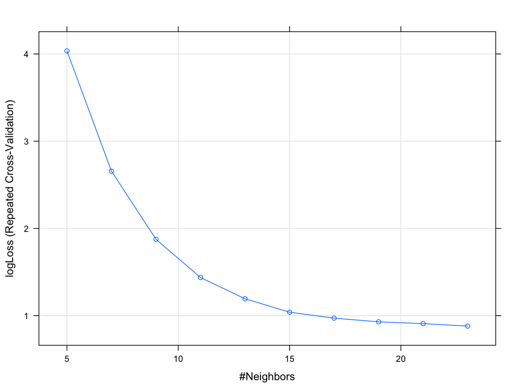

```r
#Using Elbow method to find which optimal K value
plot(knn_model)
```

```r
#making predictions
knn_pred <- predict(knn_model,test)
```

### Metric calculations

```r
#Confusion Matrix
table(knn_pred,test$FTR)
```

```
##
## knn_pred   A   D   H
##        A 141  55  42
##        D  40  56  22
##        H  75 122 358
```

```r
#calculating accuracy
mean(knn_pred==test$FTR)
```

```
## [1] 0.6092206
```

Test accuracy is aroung 60.9%

```r
#calculating Precision
Precision(y_pred=knn_pred,y_true=test$FTR)
```

```
## [1] 0.592437
```

```r
#calculating Recall
Recall(y_pred=knn_pred,y_true=test$FTR)
```

```
## [1] 0.5507812
```

```r
#calculating F1 Score
F1_Score(y_pred=knn_pred,y_true=test$FTR)
```

```
## [1] 0.5708502
```

F1 score is 57%.

### Decision Boundry

```r
model <- knn3(FTR ~ ., data=train[,c(4,5,6)], k = 1)
model1 <- knn3(FTR ~ ., data=train[,c(4,5,6)], k = 13)
```

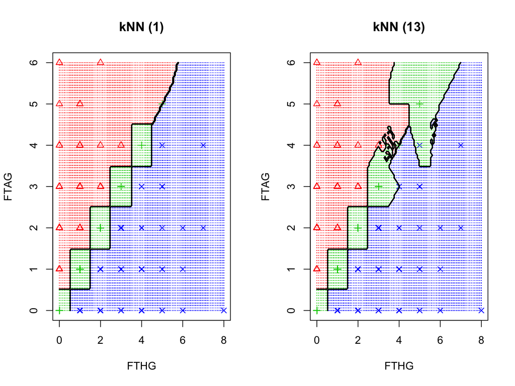

```r
par(mfrow=c(1,2))
decisionplot(model, test[,c(4,5,6)], class = "FTR", main = "kNN (1)")
decisionplot(model1, test[,c(4,5,6)], class = "FTR", main = "kNN (13)")
```

## RANDOM FOREST

### Fitting our model

```r
#fitting the model
random.fit <- randomForest(FTR~.,data=train[,c(-1,-10)],importance=TRUE)
```

```r
print(random.fit)
```

```
##
## Call:
##  randomForest(formula = FTR ~ ., data = train[, c(-1, -10)], importance = TRUE)
##                Type of random forest: classification
##                      Number of trees: 500
## No. of variables tried at each split: 4
##
##         OOB estimate of  error rate: 0.85%
## Confusion matrix:
##      A   D    H class.error
## A 1018   6    2 0.007797271
## D    7 917   10 0.018201285
## H    2   4 1683 0.003552398
```

```
## mtry = 4  OOB error = 0.88%
## Searching left ...
## mtry = 3     OOB error = 1.51%
## -0.71875 0.01
## Searching right ...
## mtry = 6     OOB error = 0.49%
## 0.4375 0.01
## mtry = 9     OOB error = 0.3%
## 0.3888889 0.01
## mtry = 13    OOB error = 0.11%
## 0.6363636 0.01
## mtry = 19    OOB error = 0.11%
## 0 0.01
```

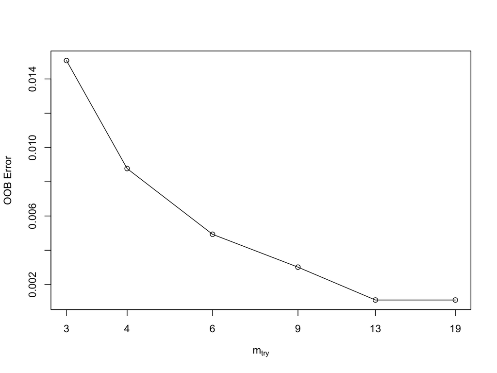

```r
#Choosing the best mtry option
mtry <- tuneRF(train[,c(-1,-10,-6)],train$FTR, ntreeTry=500,
               stepFactor=1.5,improve=0.01, trace=TRUE, plot=TRUE)
```

```r
print(mtry)
```

```
##        mtry    OOBError
## 3.OOB     3 0.015072623
## 4.OOB     4 0.008769526
## 6.OOB     6 0.004932858
## 9.OOB     9 0.003014525
## 13.OOB   13 0.001096191
## 19.OOB   19 0.001096191
```

mtry=13 has the least OOBError

```r
#Fitting the model with mtry=13
random.fit1 <- randomForest(FTR~.,data=train[,c(-1,-10)],mtry=13,importance=TRUE)
```

```r
print(random.fit1)
```

```
##
## Call:
##  randomForest(formula = FTR ~ ., data = train[, c(-1, -10)], mtry = 13,      importance = TRUE)
##                Type of random forest: classification
##                      Number of trees: 500
## No. of variables tried at each split: 13
##
##         OOB estimate of  error rate: 0.11%
## Confusion matrix:
##      A   D    H  class.error
## A 1025   0    1 0.0009746589
## D    0 932    2 0.0021413276
## H    0   1 1688 0.0005920663
```

### Variable Importance Plot

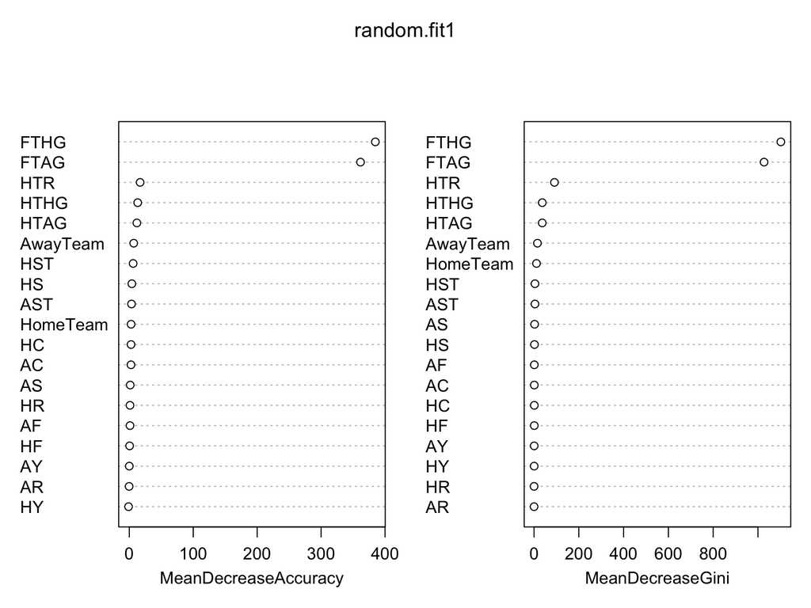

```r
#VarImpPlot is helpful to see the important variables from random forest model
varImpPlot(random.fit1)
```

Though we have many predictors Only Full time Home team goals and Full time Away goals look’s useful in predicting our end result.

```r
#Making predictions on test set
yhat.bag = predict(random.fit1 ,newdata=test[,c(-1,-10)])
```

### Metric calculations

```r
#confusion matrix
table(yhat.bag,test$FTR)
```

```
##
## yhat.bag   A   D   H
##        A 256   0   0
##        D   0 233   0
##        H   0   0 422
```

```r
#calculating accuracy.
mean(yhat.bag == test$FTR)*100
```

```
## [1] 100
```

```r
#calculating Precision
Precision(y_pred=yhat.bag,y_true=test$FTR)
```

```
## [1] 1
```

```r
#calculating Recall
Recall(y_pred=yhat.bag,y_true=test$FTR)
```

```
## [1] 1
```

```r
#calculating F1 Score
F1_Score(y_pred=yhat.bag,y_true=test$FTR)
```

```
## [1] 1
```

### Decision Boundary

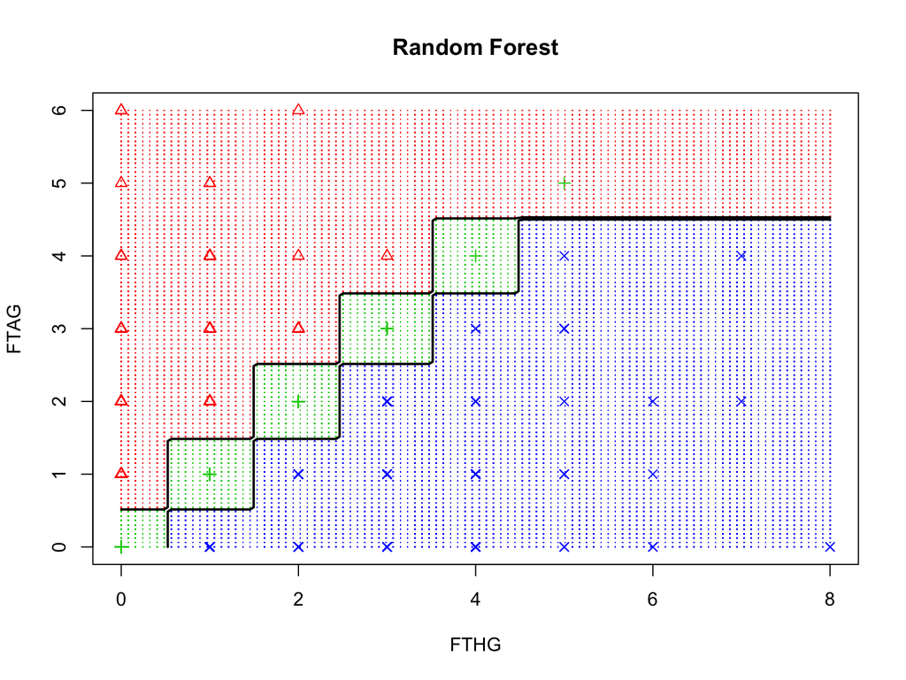

```r
#Descision Boundary
model <- randomForest(FTR ~ ., data=train[,c(4,5,6)])
decisionplot(model, test[,c(4,5,6)], class = "FTR", main = "Random Forest")
```

# Making Predictions after removing Full time, Halftime home team goals, away team goals, and Half time result.

```r
#removing Full time and half time goals
df <- seasons[,c(-1,-4,-5,-7,-8,-9,-10)]
```

```r
head(df)
```

```
##     HomeTeam      AwayTeam FTR HS AS HST AST HF AF HC AC HY AY HR AR
## 1    Arsenal   Aston Villa   D 19  5  11   3 10 19 18  1  1  2  0  0
## 2     Bolton     Tottenham   H  8  9   6   6 19 22  6  3  0  1  0  0
## 3    Everton       Watford   H  6 12   2   8 12 13  0  6  2  2  0  0
## 4  Newcastle         Wigan   H  9 14   8   9 17 20  4 11  1  2  0  0
## 5 Portsmouth     Blackburn   H 21  9  16   7 20 17  6  2  2  1  0  2
## 6    Reading Middlesbrough   H 14  7   9   5  8 15  8  2  1  3  0  0
```

### Train Test Split

```r
#splitting data into train and test
set.seed(100)
trainIndex <- createDataPartition(df$FTR,times=1,p=0.8,list=F)
train <- df[trainIndex,]
test <- df[-trainIndex,]
```

## LDA

### Fitting our model

```r
#fitting the model
lda.fit <- lda(FTR~.,data=data.frame(train))
```

```r
#making predictions on train dataset
lda.pred.train <- predict(lda.fit,train)
```

```r
#checking the accuracy in train dataset
mean(lda.pred.train$class==train$FTR)
```

```
## [1] 0.6133187
```

The accuracy is 61.3% on train data.

```r
#making predictions on test dataset
lda.pred <- predict(lda.fit,test)
```

### Metric calculations

```r
#getting predicted classes and displaying a confusion matrix
lda.class <- lda.pred$class
table(lda.class,test$FTR)
```

```
##
## lda.class   A   D   H
##         A 131  74  57
##         D  37  46  54
##         H  88 113 311
```

```r
#checking the accuracy of our results
mean(lda.class==test$FTR)
```

```
## [1] 0.5356751
```

Accuracy on a random choosen test data is 53.5%.

```r
#calculating Precision
Precision(y_pred=lda.class,y_true=test$FTR)
```

```
## [1] 0.5
```

```r
#calculating Recall
Recall(y_pred=lda.class,y_true=test$FTR)
```

```
## [1] 0.5117188
```

```r
#calculating F1 Score
F1_Score(y_pred=lda.class,y_true=test$FTR)
```

```
## [1] 0.5057915
```

### Using 10-fold cross validation on LDA.

```r
#using trainControl and train functions to find test error using 10-fold cross validation
ctrl  <- trainControl(method="cv",number = 10)
lda.fit1  <- train(FTR~.,data=train,method="lda",trControl=ctrl)
```

```r
#checing the details of the fit
lda.fit1
```

```
## Linear Discriminant Analysis
##
## 3649 samples
##   14 predictor
##    3 classes: 'A', 'D', 'H'
##
## No pre-processing
## Resampling: Cross-Validated (10 fold)
## Summary of sample sizes: 3284, 3284, 3283, 3284, 3284, 3283, ...
## Resampling results:
##
##   Accuracy   Kappa
##   0.5842567  0.3297829
```

The accuracy has improved when LDA is used with cross-validation.

```r
#making predictions on test dataset
lda.pred1 <- predict(lda.fit1,test)
```

### Metric calculations

```r
#Confusion matrix
table(lda.pred1,test$FTR)
```

```
##
## lda.pred1   A   D   H
##         A 131  74  57
##         D  37  46  54
##         H  88 113 311
```

```r
#Checking the accuracy on test dataset
mean(lda.pred1==test$FTR)
```

```
## [1] 0.5356751
```

```r
#calculating Precision
Precision(y_pred=lda.pred1,y_true=test$FTR)
```

```
## [1] 0.5
```

```r
#calculating Recall
Recall(y_pred=lda.pred1,y_true=test$FTR)
```

```
## [1] 0.5117188
```

```r
#calculating F1 Score
F1_Score(y_pred=lda.pred1,y_true=test$FTR)
```

```
## [1] 0.5057915
```

## Ridge for Mutilnomial models.

### Fitting our model

```r
#Before passing our predictors into Ridge for fitting we are converting them into matrix form
x <- model.matrix(FTR~.,data.frame(train))[,-1]
y <- train$FTR
```

```r
#Fitting the model
grid <- seq(1,100,length=100)
ridge.fit <- glmnet(x,y,alpha = 0,lambda=grid,family = "multinomial", type.multinomial = "grouped")
```

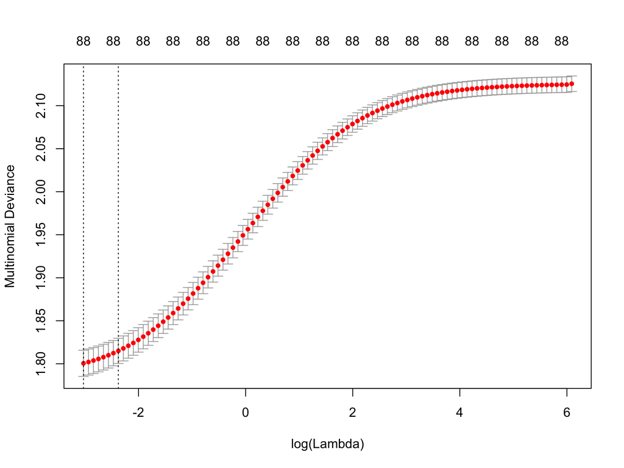

```r
#using cross validation to find the minimum lambda value
cvfit=cv.glmnet(x, y, family="multinomial",alpha=0, type.multinomial = "grouped", parallel = TRUE)
plot(cvfit)
```

```r
#Finiding Minimum lambda value
cvfit$lambda.min
```

```
## [1] 0.04842502
```

```r
#making predictions on test data using minimum lambda value
ridge.predict <- predict(cvfit, newx =  model.matrix(FTR~.,data.frame(test))[,-1], s = "lambda.min", type = "class")
```

### Metric calculations

```r
#confusion matrix
table(ridge.predict,test$FTR)
```

```
##
## ridge.predict   A   D   H
##             A 129  64  55
##             D  28  32  34
##             H  99 137 333
```

```r
#calculating test accuracy
mean(ridge.predict==test$FTR)*100
```

```
## [1] 54.22613
```

The test accuracy has resulted in around 54.22%.

```r
#calculating Precision
Precision(y_pred=ridge.predict,y_true=test$FTR)
```

```
## [1] 0.5201613
```

```r
#calculating Recall
Recall(y_pred=ridge.predict,y_true=test$FTR)
```

```
## [1] 0.5039062
```

```r
#calculating F1 Score
F1_Score(y_pred=ridge.predict,y_true=test$FTR)
```

```
## [1] 0.5119048
```

## NaiveBayes

### Fitting our model

```r
#Fitting a model
nb_model<-naiveBayes(FTR~.,data=train)
```

```r
#making predictions
nb_test_predict <- predict(nb_model,test)
```

### Metric calculations

```r
#Confusion Matrix
conf_matrix <- table(nb_test_predict, test$FTR)
conf_matrix
```

```
##
## nb_test_predict   A   D   H
##               A 138  72  93
##               D  26  38  37
##               H  92 123 292
```

```r
#calculating accuracy on test data
mean(nb_test_predict==test$FTR)*100
```

```
## [1] 51.37212
```

It has an accuracy of 51.3% on test data.

```r
#calculating Precision
Precision(y_pred=nb_test_predict,y_true=test$FTR)
```

```
## [1] 0.4554455
```

```r
#calculating Recall
Recall(y_pred=nb_test_predict,y_true=test$FTR)
```

```
## [1] 0.5390625
```

```r
#calculating F1 Score
F1_Score(y_pred=nb_test_predict,y_true=test$FTR)
```

```
## [1] 0.4937388
```

## KNN

### Fitting our model

```r
#using trainControl and train functions to find test error using 10-fold cross validation
repeats = 3
numbers = 10
tunel = 10

x = trainControl(method = "repeatedcv",
                 number = numbers,
                 repeats = repeats,
                 classProbs = TRUE,
                 summaryFunction = multiClassSummary)
```

```r
knn_model <- train(FTR~. , data = train, method = "knn",
               preProcess = c("center","scale"),
               trControl = x,
               metric = "logLoss",
               tuneLength = tunel)
```

```r
#summary of the model
knn_model
```

```
## k-Nearest Neighbors
##
## 3649 samples
##   14 predictor
##    3 classes: 'A', 'D', 'H'
##
## Pre-processing: centered (88), scaled (88)
## Resampling: Cross-Validated (10 fold, repeated 3 times)
## Summary of sample sizes: 3284, 3284, 3285, 3283, 3283, 3284, ...
## Resampling results across tuning parameters:
##
##   k   logLoss   AUC        prAUC      Accuracy   Kappa      Mean_F1
##    5  5.360872  0.6366258  0.4143113  0.4980398  0.2005906  0.4490683
##    7  3.442706  0.6484127  0.4479694  0.5094551  0.2121682  0.4528292
##    9  2.501585  0.6508000  0.4551733  0.5099965  0.2074338  0.4453237
##   11  1.966185  0.6520052  0.4612511  0.5091786  0.2032283  0.4401580
##   13  1.584963  0.6515268  0.4641326  0.5100000  0.2023941  0.4373971
##   15  1.346453  0.6546294  0.4712646  0.5162161  0.2112009  0.4433670
##   17  1.220545  0.6538932  0.4712353  0.5148377  0.2064579  0.4360386
##   19  1.132738  0.6554274  0.4718731  0.5205957  0.2143517  0.4391942
##   21  1.069402  0.6590935  0.4728893  0.5225137  0.2166109  0.4403980
##   23  1.048004  0.6604145  0.4748888  0.5245256  0.2187990  0.4392936
##   Mean_Sensitivity  Mean_Specificity  Mean_Pos_Pred_Value
##   0.4547173         0.7347630         0.4514395
##   0.4599792         0.7383502         0.4595629
##   0.4554202         0.7364077         0.4546446
##   0.4517574         0.7349584         0.4509346
##   0.4504172         0.7347141         0.4477374
##   0.4564595         0.7372186         0.4567465
##   0.4524039         0.7356630         0.4497855
##   0.4567567         0.7381722         0.4563072
##   0.4586809         0.7386023         0.4588358
##   0.4594057         0.7393235         0.4614002
##   Mean_Neg_Pred_Value  Mean_Precision  Mean_Recall  Mean_Detection_Rate
##   0.7401954            0.4514395       0.4547173    0.1660133
##   0.7465809            0.4595629       0.4599792    0.1698184
##   0.7468987            0.4546446       0.4554202    0.1699988
##   0.7468294            0.4509346       0.4517574    0.1697262
##   0.7476542            0.4477374       0.4504172    0.1700000
##   0.7508330            0.4567465       0.4564595    0.1720720
##   0.7506748            0.4497855       0.4524039    0.1716126
##   0.7546197            0.4563072       0.4567567    0.1735319
##   0.7553969            0.4588358       0.4586809    0.1741712
##   0.7570782            0.4614002       0.4594057    0.1748419
##   Mean_Balanced_Accuracy
##   0.5947402
##   0.5991647
##   0.5959139
##   0.5933579
##   0.5925656
##   0.5968391
##   0.5940334
##   0.5974644
##   0.5986416
##   0.5993646
##
## logLoss was used to select the optimal model using the smallest value.
## The final value used for the model was k = 23.
```

### Using the Elbow method to find best K-value

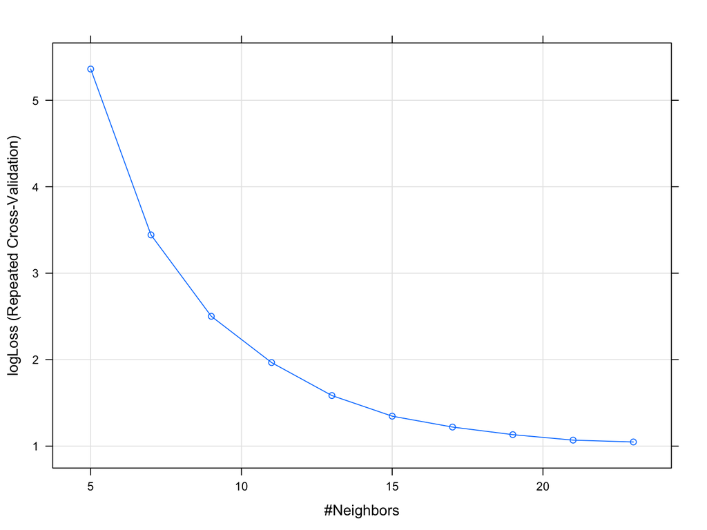

```r
#Using Elbow method to find which optimal K value
plot(knn_model)
```

```r
#making predictions
knn_pred <- predict(knn_model,test)
```

### Metric calculations

```r
#Confusion Matrix
table(knn_pred,test$FTR)
```

```
##
## knn_pred   A   D   H
##        A 109  54  73
##        D  33  32  35
##        H 114 147 314
```

```r
#calculating accuracy
mean(knn_pred==test$FTR)
```

```
## [1] 0.4994512
```

Test accuracy is aroung 49.9%

```r
#calculating Precision
Precision(y_pred=knn_pred,y_true=test$FTR)
```

```
## [1] 0.4618644
```

```r
#calculating Recall
Recall(y_pred=knn_pred,y_true=test$FTR)
```

```
## [1] 0.4257812
```

```r
#calculating F1 Score
F1_Score(y_pred=knn_pred,y_true=test$FTR)
```

```
## [1] 0.4430894
```

F1 score is 44.3%.

## RANDOM FOREST

### Fitting our model

```r
#fitting the model
random.fit <- randomForest(FTR~.,data=train,importance=TRUE)
```

```r
print(random.fit)
```

```
##
## Call:
##  randomForest(formula = FTR ~ ., data = train, importance = TRUE)
##                Type of random forest: classification
##                      Number of trees: 500
## No. of variables tried at each split: 3
##
##         OOB estimate of  error rate: 37.6%
## Confusion matrix:
##     A   D    H class.error
## A 635  83  308   0.3810916
## D 241 206  487   0.7794433
## H 164  89 1436   0.1497928
```

```r
#Fitting the model with mtry=13
random.fit1 <- randomForest(FTR~.,data=train,mtry=4,importance=TRUE)
```

```r
print(random.fit1)
```

```
##
## Call:
##  randomForest(formula = FTR ~ ., data = train, mtry = 4, importance = TRUE)
##                Type of random forest: classification
##                      Number of trees: 500
## No. of variables tried at each split: 4
##
##         OOB estimate of  error rate: 37.82%
## Confusion matrix:
##     A   D    H class.error
## A 636  97  293   0.3801170
## D 246 213  475   0.7719486
## H 177  92 1420   0.1592658
```

### Variable Importance Plot

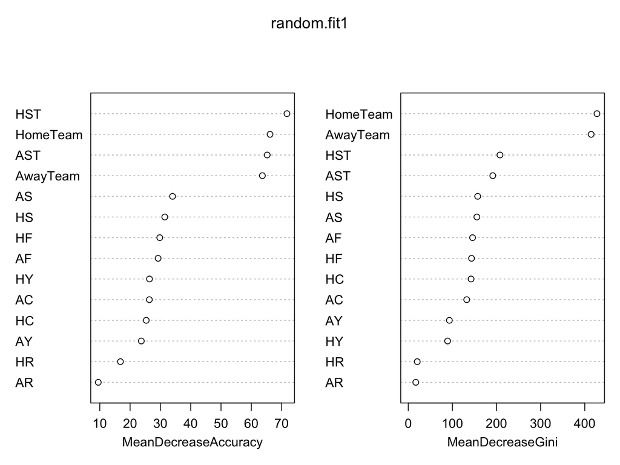

```r
#VarImpPlot is helpful to see the important variables from random forest model
varImpPlot(random.fit1)
```

```r
#Making predictions on test set
yhat.bag = predict(random.fit1 ,newdata=test)
```

### Metric calculations

```r
#confusion matrix
table(yhat.bag,test$FTR)
```

```
##
## yhat.bag   A   D   H
##        A 155  60  60
##        D  18  57  18
##        H  83 116 344
```

```r
#calculating accuracy.
mean(yhat.bag == test$FTR)*100
```

```
## [1] 61.03183
```

Random forest has an accuracy of 61.03%

```r
#calculating Precision
Precision(y_pred=yhat.bag,y_true=test$FTR)
```

```
## [1] 0.5636364
```

```r
#calculating Recall
Recall(y_pred=yhat.bag,y_true=test$FTR)
```

```
## [1] 0.6054688
```

```r
#calculating F1 Score
F1_Score(y_pred=yhat.bag,y_true=test$FTR)
```

```
## [1] 0.5838041
```